# Statistical Analysis Handout for the Market Segmentation Lecture

## Find the optimal number of clusters

A key question when using the K-Means clustering technique consists in choosing the optimal number of segments. In order to do that, we can use the function NbClust() as in hierarchical clustering by specifying the method kmeans as below. From the output, We see that the three-cluster solution is best.

```
*** : The Hubert index is a graphical method of determining the number of clusters.
                In the plot of Hubert index, we seek a significant knee that corresponds to a
                significant increase of the value of the measure i.e the significant peak in Hubert
                index second differences plot.
```

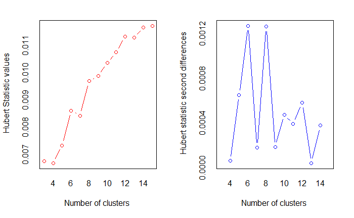

```
*** : The D index is a graphical method of determining the number of clusters.
                In the plot of D index, we seek a significant knee (the significant peak in Dindex
                second differences plot) that corresponds to a significant increase of the value of
                the measure.

* Among all indices:
* 6 proposed 3 as the best number of clusters
* 2 proposed 4 as the best number of clusters
* 2 proposed 6 as the best number of clusters
* 2 proposed 7 as the best number of clusters
* 1 proposed 8 as the best number of clusters
* 4 proposed 9 as the best number of clusters
* 3 proposed 12 as the best number of clusters
* 1 proposed 14 as the best number of clusters
* 2 proposed 15 as the best number of clusters

                   ***** Conclusion *****

* According to the majority rule, the best number of clusters is  3


$All.index
        KL      CH Hartigan     CCC    Scott   Marriot    TrCovW   TraceW Friedman  Rubin Cindex     DB Silhouette   Duda Pseudot2   Beale Ratkowsky    Ball Ptbiserial
3   3.1498 23.0027   7.3428 -2.3384 161.6503 332431565 3142.6116 217.2313   6.9183 1.6572 0.4029 1.6368     0.2211 1.0507  -1.3022 -0.1441    0.3612 72.4104     0.4486
4   0.2773 19.1143  10.8179 -4.1279 180.6433 455602252 2468.6196 196.6077   7.7155 1.8311 0.3869 1.5041     0.1990 0.7855   5.4612  0.8096    0.3364 49.1519     0.4286
5   1.1109 19.0082   9.1739 -4.3782 226.2606 381081231 1799.8257 169.9611   9.7872 2.1181 0.3706 1.3221     0.2162 1.2449  -6.0986 -0.5911    0.3244 33.9922     0.4617
6   6.4228 18.8121   3.6552 -3.8518 269.2067 304707497 1390.9150 149.7572  12.0951 2.4039 0.3889 1.3359     0.2354 0.9319   2.3401  0.2136    0.3111 24.9595     0.5207
7   0.0909 16.8854  10.8081 -4.5792 285.0705 333733429 1207.4155 142.0098  13.1540 2.5350 0.3361 1.1942     0.2219 1.6849  -5.2846 -1.1309    0.2940 20.2871     0.4843
8   2.0419 18.1088   6.7638 -3.3362 332.9957 226081272  887.3273 122.0267  15.5631 2.9502 0.3971 1.1485     0.2512 1.9582  -5.8718 -1.2252    0.2874 15.2533     0.5417
9   1.5344 18.0573   5.1548 -3.0019 360.8499 195370275  716.6992 110.5256  16.7760 3.2572 0.4358 1.0891     0.2564 1.1275  -3.5052 -0.3408    0.2775 12.2806     0.5469
10  0.8036 17.6366   5.5133 -2.9718 388.0749 166113771  618.2108 102.2870  18.3653 3.5195 0.4254 1.1107     0.2495 1.0614  -1.5626 -0.1736    0.2675 10.2287     0.5239
11  0.7242 17.5306   6.6341 -2.7786 417.0160 135211375  518.8685  94.0559  20.3099 3.8275 0.4169 1.1145     0.2182 2.2790  -5.0509 -0.8782    0.2591  8.5505     0.4801
12 24.6647 17.9510   1.8086 -2.2654 440.7721 116214349  404.6106  84.9646  21.4626 4.2371 0.4583 1.0912     0.2373 1.7334  -3.3847 -0.9931    0.2523  7.0804     0.4422
13  0.0943 16.8134   3.6940 -2.8622 454.4743 113048822  387.8180  82.5180  22.4283 4.3627 0.4728 1.1208     0.2047 1.6787  -0.8086 -1.0123    0.2435  6.3475     0.3942
14  0.6684 16.4804   4.5566 -2.9399 468.3727 108380371  332.1539  77.7323  22.8790 4.6313 0.4495 1.0774     0.2108 0.8208   0.8735  0.5126    0.2366  5.5523     0.4009
15  1.0729 16.5257   4.2987 -2.7712 503.6448  76742295  296.7175  72.1593  26.2250 4.9890 0.4372 1.0150     0.2286 3.6908  -1.4581 -1.1409    0.2308  4.8106     0.4069
      Frey McClain   Dunn Hubert SDindex Dindex   SDbw
3   0.8038  1.2726 0.1677 0.0068  2.1651 1.5698 0.9262
4   0.0633  1.7159 0.1591 0.0067  1.9266 1.5045 0.6658
5  -0.2047  1.9725 0.1651 0.0073  1.7716 1.4061 0.6320
```

[output cut: 25 more lines]

```
15        -0.1969           -12.1574       1.0000

$Best.nc
                     KL      CH Hartigan     CCC   Scott   Marriot  TrCovW  TraceW Friedman   Rubin Cindex     DB Silhouette   Duda PseudoT2   Beale Ratkowsky    Ball
Number_clusters 12.0000  3.0000   7.0000 12.0000  8.0000         6   4.000  6.0000   15.000 12.0000 7.0000 15.000     9.0000 3.0000   3.0000  3.0000    3.0000  4.0000
Value_Index     24.6647 23.0027   7.1529 -2.2654 47.9253 105399665 673.992 12.4564    3.346 -0.2839 0.3361  1.015     0.2564 1.0507  -1.3022 -0.1441    0.3612 23.2585
                PtBiserial Frey McClain   Dunn Hubert SDindex Dindex    SDbw
Number_clusters     9.0000    2  3.0000 9.0000      0  9.0000      0 14.0000
Value_Index         0.5469   NA  1.2726 0.2431      0  1.5509      0  0.2546

$Best.partition
 1  2  3  4  5  6  7  8  9 10 11 12 13 14 15 16 17 18 19 20 21 22 23 24 25 26 27 28 29 30 31 32 33 34 35 36 37 38 39 40 41 42 43 44 45 46 47 48 49 50 51 52 53 54 55 56
 3  3  1  3  3  1  2  3  3  2  3  2  2  1  3  2  1  2  2  1  3  2  3  3  2  1  2  1  3  2  1  1  3  1  1  2  3  2  2  2  2  3  2  3  1  3  2  2  1  2  2  1  2  2  2  2
57 58 59 60 61 62 63 64 65 66 67 68 69 70 71 72 73
 1  2  2  1  1  1  2  1  1  2  2  1  2  1  2  1  3
```

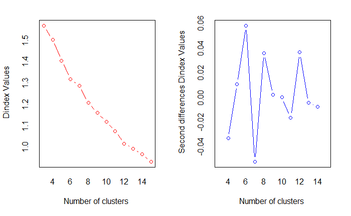

```r
set.seed(1990)
NbClust(data=std_seg_data[,1:5], min.nc=3, max.nc=15, index="all", method="kmeans")
```

## Results Comparison

### Demographics

```r
CrossTable(seg_data$MBA,Kmean_Cluster,prop.chisq = FALSE, prop.r = T, prop.c = T,
           prop.t = F,chisq = T)
```

```
   Cell Contents
|-------------------------|
|                       N |
|           N / Row Total |
|           N / Col Total |
|-------------------------|


Total Observations in Table:  73


             | Kmean_Cluster
seg_data$MBA |      Perf. KM |    Comfort KM | Appearance KM |     Row Total |
-------------|---------------|---------------|---------------|---------------|
         MBA |             5 |             8 |            11 |            24 |
             |         0.208 |         0.333 |         0.458 |         0.329 |
             |         0.217 |         0.250 |         0.611 |               |
-------------|---------------|---------------|---------------|---------------|
   Undergrad |            18 |            24 |             7 |            49 |
             |         0.367 |         0.490 |         0.143 |         0.671 |
             |         0.783 |         0.750 |         0.389 |               |
-------------|---------------|---------------|---------------|---------------|
Column Total |            23 |            32 |            18 |            73 |
             |         0.315 |         0.438 |         0.247 |               |
-------------|---------------|---------------|---------------|---------------|


Statistics for All Table Factors


Pearson's Chi-squared test
------------------------------------------------------------
Chi^2 =  8.694824     d.f. =  2     p =  0.01294026
```

### Choice

```r
CrossTable(Kmean_Cluster,seg_data$Choice,prop.chisq = FALSE, prop.r = T, prop.c = T,prop.t = F,chisq = T)
```

```
   Cell Contents
|-------------------------|
|                       N |
|           N / Row Total |
|           N / Col Total |
|-------------------------|


Total Observations in Table:  73


              | seg_data$Choice
Kmean_Cluster |       BMW |     Lexus |  Mercedes | Row Total |
--------------|-----------|-----------|-----------|-----------|
     Perf. KM |        11 |         6 |         6 |        23 |
              |     0.478 |     0.261 |     0.261 |     0.315 |
              |     0.344 |     0.273 |     0.316 |           |
--------------|-----------|-----------|-----------|-----------|
   Comfort KM |        14 |         8 |        10 |        32 |
              |     0.438 |     0.250 |     0.312 |     0.438 |
              |     0.438 |     0.364 |     0.526 |           |
--------------|-----------|-----------|-----------|-----------|
Appearance KM |         7 |         8 |         3 |        18 |
              |     0.389 |     0.444 |     0.167 |     0.247 |
              |     0.219 |     0.364 |     0.158 |           |
--------------|-----------|-----------|-----------|-----------|
 Column Total |        32 |        22 |        19 |        73 |
              |     0.438 |     0.301 |     0.260 |           |
--------------|-----------|-----------|-----------|-----------|


Statistics for All Table Factors


Pearson's Chi-squared test
------------------------------------------------------------
Chi^2 =  2.753465     d.f. =  4     p =  0.5998918
```

### Hierarchical Clustering

```r
CrossTable(h_cluster,Kmean_Cluster,prop.chisq = FALSE, prop.r = T, prop.c = T,
           prop.t = F,chisq = T)
```

```
   Cell Contents
|-------------------------|
|                       N |
|           N / Row Total |
|           N / Col Total |
|-------------------------|


Total Observations in Table:  73


             | Kmean_Cluster
   h_cluster |      Perf. KM |    Comfort KM | Appearance KM |     Row Total |
-------------|---------------|---------------|---------------|---------------|
       Perf. |             7 |             3 |            17 |            27 |
             |         0.259 |         0.111 |         0.630 |         0.370 |
             |         0.304 |         0.094 |         0.944 |               |
-------------|---------------|---------------|---------------|---------------|
     Comfort |             1 |            27 |             1 |            29 |
             |         0.034 |         0.931 |         0.034 |         0.397 |
             |         0.043 |         0.844 |         0.056 |               |
-------------|---------------|---------------|---------------|---------------|
  Appearance |            15 |             2 |             0 |            17 |
             |         0.882 |         0.118 |         0.000 |         0.233 |
             |         0.652 |         0.062 |         0.000 |               |
-------------|---------------|---------------|---------------|---------------|
Column Total |            23 |            32 |            18 |            73 |
             |         0.315 |         0.438 |         0.247 |               |
-------------|---------------|---------------|---------------|---------------|


Statistics for All Table Factors


Pearson's Chi-squared test
------------------------------------------------------------
Chi^2 =  77.06958     d.f. =  4     p =  7.26997e-16
```

# Latent Class Analysis (requires alot of sample size)

Latent Class Analysis is a method to identify cluster membership of subjects using the observable variables that describe them. The approach consists in estimating for each individual the probability to belong to a “latent class” or cluster. In turn, each cluster is defined in terms of its “geometry” and “orientation” as cloud of points. As such, this technique belongs to the family of gaussian finite mixture models. This approach relies on a different optimization procedure that aims to maximize the likelihood (versus minimize the distances between each point). Hence, the tools to assess the optimal number of classes differ. We now perform this analysis using the package mclust. We start by determining the optimal model based on BIC using the function mclustBIC().

## Find the optimal model

```r
set.seed(1990)
mclustBIC(std_seg_data[,1:5],verbose=F)
```

```
Bayesian Information Criterion (BIC):
        EII       VII       EEI       VEI       EVI       VVI        EEE        EVE        VEE        VVE        EEV        VEV        EVV        VVV
1 -1056.533 -1056.533 -1073.695 -1073.695 -1073.695 -1073.695  -989.2715  -989.2715  -989.2715  -989.2715  -989.2715  -989.2715  -989.2715  -989.2715
2 -1044.385 -1034.168 -1056.372 -1050.677 -1068.373        NA  -990.8975  -996.8014  -979.6149  -991.0417 -1032.1826 -1005.9074 -1024.5619 -1018.3899
3 -1057.222 -1029.139 -1071.169 -1044.311 -1089.704        NA -1008.7262 -1008.1715  -993.3826 -1011.2738 -1050.0593 -1034.8899 -1059.0820 -1063.0796
4 -1064.983 -1044.525 -1078.038 -1064.423 -1108.803        NA -1028.1713 -1038.1202 -1011.4423 -1019.0960 -1093.9419 -1068.0324 -1146.3233 -1131.7445
5 -1080.202 -1061.797 -1080.862 -1060.161 -1124.698 -1121.160 -1047.2033 -1091.0091 -1022.3139 -1082.0679 -1095.1872 -1105.4331 -1165.1084 -1164.0991
6 -1089.708 -1064.796 -1092.258 -1076.814        NA -1139.229 -1036.1117         NA         NA         NA -1147.1214 -1145.2057         NA         NA
7 -1102.008 -1081.225 -1105.792 -1096.170 -1161.701 -1171.419 -1071.1169         NA         NA         NA -1179.3820 -1174.0053         NA         NA
8 -1110.198 -1095.876 -1102.764 -1109.633 -1167.466        NA -1076.7272         NA         NA         NA -1221.1374 -1181.0816         NA         NA
9 -1135.082        NA -1113.473 -1134.105        NA        NA -1098.6670         NA         NA         NA -1183.2994 -1244.9437         NA         NA

Top 3 models based on the BIC criterion:
    VEE,2     EEE,1     EEV,1
-979.6149 -989.2715 -989.2715
```

```r
set.seed(1990)
lca_clust <- Mclust(std_seg_data[,1:5],verbose = FALSE)
summary(lca_clust)
```

```
----------------------------------------------------
Gaussian finite mixture model fitted by EM algorithm
----------------------------------------------------

Mclust VEE (ellipsoidal, equal shape and orientation) model with 2 components:
```

|  | log-likelihood | n | df | BIC | ICL |
| --- | --- | --- | --- | --- | --- |
|  | -431.8862 | 73 | 27 | -979.6149 | -990.9626 |

```
Clustering table:
 1  2
47 26
```

We now interpret each cluster and rename them to describe them accurately:

```r
lca_clusters <- lca_clust$classification
lca_clust_summary <- aggregate(std_seg_data[,c("Trendy", "Styling", "Reliability", "Sportiness", "Performance", "Comfort")],by=list(lca_clusters),FUN=mean)
lca_clust_summary
```

| Group.1 | Trendy | Styling | Reliability | Sportiness | Performance | Comfort |
| --- | --- | --- | --- | --- | --- | --- |
| 1 | 0.02627812 | 0.2424889 | 0.1364223 | -0.2787552 | -0.04411188 | -0.1929288 |
| 2 | -0.04750275 | -0.4383453 | -0.2466095 | 0.5039037 | 0.07974071 | 0.3487559 |

```r
lca_clusters<-factor(lca_clusters,levels = c(1,2),
                    labels = c("Reliability LCA", "Comfort LCA"))
```

## Results Comparison

Let us compare this solution to the demographics and choice data as well as the hierarchical clustering and K-Means:

### Demographics

```r
CrossTable(seg_data$MBA,lca_clusters,prop.chisq = FALSE, prop.r = T, prop.c = T,
           prop.t = F,chisq = T)
```

```
   Cell Contents
|-------------------------|
|                       N |
|           N / Row Total |
|           N / Col Total |
|-------------------------|


Total Observations in Table:  73


             | lca_clusters
seg_data$MBA | Reliability LCA |     Comfort LCA |       Row Total |
-------------|-----------------|-----------------|-----------------|
         MBA |              20 |               4 |              24 |
             |           0.833 |           0.167 |           0.329 |
             |           0.426 |           0.154 |                 |
-------------|-----------------|-----------------|-----------------|
   Undergrad |              27 |              22 |              49 |
             |           0.551 |           0.449 |           0.671 |
             |           0.574 |           0.846 |                 |
-------------|-----------------|-----------------|-----------------|
Column Total |              47 |              26 |              73 |
             |           0.644 |           0.356 |                 |
-------------|-----------------|-----------------|-----------------|


Statistics for All Table Factors


Pearson's Chi-squared test
------------------------------------------------------------
Chi^2 =  5.599129     d.f. =  1     p =  0.01796941

Pearson's Chi-squared test with Yates' continuity correction
------------------------------------------------------------
Chi^2 =  4.435671     d.f. =  1     p =  0.03519539
```

### Choice

```r
CrossTable(lca_clusters,seg_data$Choice,prop.chisq = FALSE, prop.r = T, prop.c = T,
           prop.t = F,chisq = T)
```

```
   Cell Contents
|-------------------------|
|                       N |
|           N / Row Total |
|           N / Col Total |
|-------------------------|


Total Observations in Table:  73


                | seg_data$Choice
   lca_clusters |       BMW |     Lexus |  Mercedes | Row Total |
----------------|-----------|-----------|-----------|-----------|
Reliability LCA |        21 |        17 |         9 |        47 |
                |     0.447 |     0.362 |     0.191 |     0.644 |
                |     0.656 |     0.773 |     0.474 |           |
----------------|-----------|-----------|-----------|-----------|
    Comfort LCA |        11 |         5 |        10 |        26 |
                |     0.423 |     0.192 |     0.385 |     0.356 |
                |     0.344 |     0.227 |     0.526 |           |
----------------|-----------|-----------|-----------|-----------|
   Column Total |        32 |        22 |        19 |        73 |
                |     0.438 |     0.301 |     0.260 |           |
----------------|-----------|-----------|-----------|-----------|


Statistics for All Table Factors


Pearson's Chi-squared test
------------------------------------------------------------
Chi^2 =  4.014183     d.f. =  2     p =  0.134379
```

### Hierarchical Clustering

```r
CrossTable(h_cluster,lca_clusters,prop.chisq = FALSE, prop.r = T, prop.c = T,
           prop.t = F,chisq = T)
```

```
   Cell Contents
|-------------------------|
|                       N |
|           N / Row Total |
|           N / Col Total |
|-------------------------|


Total Observations in Table:  73


             | lca_clusters
   h_cluster | Reliability LCA |     Comfort LCA |       Row Total |
-------------|-----------------|-----------------|-----------------|
       Perf. |              24 |               3 |              27 |
             |           0.889 |           0.111 |           0.370 |
             |           0.511 |           0.115 |                 |
-------------|-----------------|-----------------|-----------------|
     Comfort |               6 |              23 |              29 |
             |           0.207 |           0.793 |           0.397 |
             |           0.128 |           0.885 |                 |
-------------|-----------------|-----------------|-----------------|
  Appearance |              17 |               0 |              17 |
             |           1.000 |           0.000 |           0.233 |
             |           0.362 |           0.000 |                 |
-------------|-----------------|-----------------|-----------------|
Column Total |              47 |              26 |              73 |
             |           0.644 |           0.356 |                 |
-------------|-----------------|-----------------|-----------------|


Statistics for All Table Factors


Pearson's Chi-squared test
------------------------------------------------------------
Chi^2 =  40.61918     d.f. =  2     p =  1.512363e-09
```

### K-Means Clustering

```r
CrossTable(Kmean_Cluster,lca_clusters,prop.chisq = FALSE, prop.r = T, prop.c = T,
           prop.t = F,chisq = T)
```

```
   Cell Contents
|-------------------------|
|                       N |
|           N / Row Total |
|           N / Col Total |
|-------------------------|


Total Observations in Table:  73


              | lca_clusters
Kmean_Cluster | Reliability LCA |     Comfort LCA |       Row Total |
--------------|-----------------|-----------------|-----------------|
     Perf. KM |              22 |               1 |              23 |
              |           0.957 |           0.043 |           0.315 |
              |           0.468 |           0.038 |                 |
--------------|-----------------|-----------------|-----------------|
   Comfort KM |               9 |              23 |              32 |
              |           0.281 |           0.719 |           0.438 |
              |           0.191 |           0.885 |                 |
--------------|-----------------|-----------------|-----------------|
Appearance KM |              16 |               2 |              18 |
              |           0.889 |           0.111 |           0.247 |
              |           0.340 |           0.077 |                 |
--------------|-----------------|-----------------|-----------------|
 Column Total |              47 |              26 |              73 |
              |           0.644 |           0.356 |                 |
--------------|-----------------|-----------------|-----------------|


Statistics for All Table Factors


Pearson's Chi-squared test
------------------------------------------------------------
Chi^2 =  32.86657     d.f. =  2     p =  7.296505e-08
```

# HDBSCAN

references: https://hdbscan.readthedocs.io/en/latest/how_hdbscan_works.html https://cran.r-project.org/web/packages/dbscan/vignettes/hdbscan.html

```r
# for (pts in 2:20) {
#   hdbscan_clust <- hdbscan(std_seg_data, minPts = pts)
#   print(hdbscan_clust)
#   plot(hdbscan_clust$hc, main = paste0("minPts: ", pts))
#   try(plot(hdbscan_clust, show_flat = T))
# }

minPts = 2

hdbscan_clust_final <- hdbscan(std_seg_data, minPts = minPts)
print(hdbscan_clust_final)
```

```
HDBSCAN clustering for 73 objects.
Parameters: minPts = 2
The clustering contains 7 cluster(s) and 12 noise points.

 0  1  2  3  4  5  6  7
12  2  2  2  6  2 45  2

Available fields: cluster, minPts, cluster_scores, membership_prob, outlier_scores, hc
```

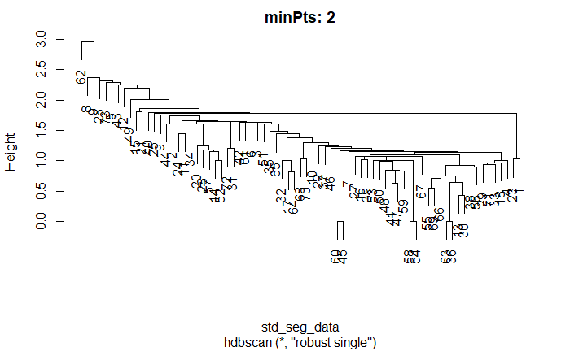

```r
plot(hdbscan_clust_final$hc, main = paste0("minPts: ", minPts))
```

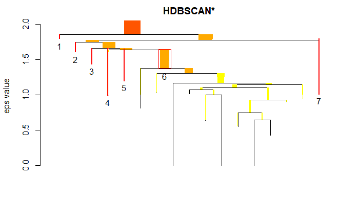

```r
plot(hdbscan_clust_final, show_flat = T)
```

```r
hdbscan_clusters <- hdbscan_clust_final$cluster
hdbscan_summary <- aggregate(std_seg_data[,c("Trendy", "Styling", "Reliability", "Sportiness", "Performance", "Comfort")],by=list(hdbscan_clusters),FUN=mean)
hdbscan_summary
```

| Group.1 | Trendy | Styling | Reliability | Sportiness | Performance | Comfort |
| --- | --- | --- | --- | --- | --- | --- |
| 0 | -0.51929880 | 0.33488125 | 0.2261888 | -0.1173536 | 0.39488214 | -0.42511930 |
| 1 | -1.67519913 | -1.27343001 | 2.4708507 | -1.5560545 | 0.82808260 | 0.93899976 |
| 2 | 1.08480777 | -1.91675451 | 0.7080272 | -1.1636815 | 0.45676792 | 0.42745512 |
| 3 | -1.67519913 | 0.09363456 | 0.7080272 | -0.7713085 | 0.82808260 | 0.93899976 |
| 4 | 1.79250185 | 0.22766050 | -0.1146238 | -0.5097266 | -1.07799942 | -0.69794311 |
| 5 | -1.03827446 | 2.10402363 | -0.3496669 | -0.6732153 | 0.08545324 | -0.08408953 |
| 6 | 0.07673687 | -0.09757578 | -0.2963905 | 0.3360552 | -0.04656976 | 0.15690484 |
| 7 | -0.68442742 | 0.49571237 | 2.1182860 | -1.1636815 | -0.28586144 | -1.10717882 |

```r
# lca_clusters<-factor(lca_clusters,levels = c(1,2),
#                     labels = c("Reliability LCA", "Comfort LCA"))
```

```r
CrossTable(seg_data$MBA,hdbscan_clust_final$cluster,prop.chisq = FALSE, prop.r = T, prop.c = T,
           prop.t = F,chisq = T)
```

```
Chi-squared approximation may be incorrect
```

```
   Cell Contents
|-------------------------|
|                       N |
|           N / Row Total |
|           N / Col Total |
|-------------------------|


Total Observations in Table:  73


             | hdbscan_clust_final$cluster
seg_data$MBA |         0 |         1 |         2 |         3 |         4 |         5 |         6 |         7 | Row Total |
-------------|-----------|-----------|-----------|-----------|-----------|-----------|-----------|-----------|-----------|
         MBA |         5 |         2 |         1 |         2 |         2 |         0 |        10 |         2 |        24 |
             |     0.208 |     0.083 |     0.042 |     0.083 |     0.083 |     0.000 |     0.417 |     0.083 |     0.329 |
             |     0.417 |     1.000 |     0.500 |     1.000 |     0.333 |     0.000 |     0.222 |     1.000 |           |
-------------|-----------|-----------|-----------|-----------|-----------|-----------|-----------|-----------|-----------|
   Undergrad |         7 |         0 |         1 |         0 |         4 |         2 |        35 |         0 |        49 |
             |     0.143 |     0.000 |     0.020 |     0.000 |     0.082 |     0.041 |     0.714 |     0.000 |     0.671 |
             |     0.583 |     0.000 |     0.500 |     0.000 |     0.667 |     1.000 |     0.778 |     0.000 |           |
-------------|-----------|-----------|-----------|-----------|-----------|-----------|-----------|-----------|-----------|
Column Total |        12 |         2 |         2 |         2 |         6 |         2 |        45 |         2 |        73 |
             |     0.164 |     0.027 |     0.027 |     0.027 |     0.082 |     0.027 |     0.616 |     0.027 |           |
-------------|-----------|-----------|-----------|-----------|-----------|-----------|-----------|-----------|-----------|


Statistics for All Table Factors


Pearson's Chi-squared test
------------------------------------------------------------
Chi^2 =  16.23084     d.f. =  7     p =  0.02308902
```

```r
CrossTable(h_cluster,hdbscan_clust_final$cluster,prop.chisq = FALSE, prop.r = T, prop.c = T,
           prop.t = F,chisq = T)
```

```
Chi-squared approximation may be incorrect
```

```
   Cell Contents
|-------------------------|
|                       N |
|           N / Row Total |
|           N / Col Total |
|-------------------------|


Total Observations in Table:  73


             | hdbscan_clust_final$cluster
   h_cluster |         0 |         1 |         2 |         3 |         4 |         5 |         6 |         7 | Row Total |
-------------|-----------|-----------|-----------|-----------|-----------|-----------|-----------|-----------|-----------|
       Perf. |         8 |         2 |         2 |         2 |         0 |         2 |         9 |         2 |        27 |
             |     0.296 |     0.074 |     0.074 |     0.074 |     0.000 |     0.074 |     0.333 |     0.074 |     0.370 |
             |     0.667 |     1.000 |     1.000 |     1.000 |     0.000 |     1.000 |     0.200 |     1.000 |           |
-------------|-----------|-----------|-----------|-----------|-----------|-----------|-----------|-----------|-----------|
     Comfort |         2 |         0 |         0 |         0 |         0 |         0 |        27 |         0 |        29 |
             |     0.069 |     0.000 |     0.000 |     0.000 |     0.000 |     0.000 |     0.931 |     0.000 |     0.397 |
             |     0.167 |     0.000 |     0.000 |     0.000 |     0.000 |     0.000 |     0.600 |     0.000 |           |
-------------|-----------|-----------|-----------|-----------|-----------|-----------|-----------|-----------|-----------|
  Appearance |         2 |         0 |         0 |         0 |         6 |         0 |         9 |         0 |        17 |
             |     0.118 |     0.000 |     0.000 |     0.000 |     0.353 |     0.000 |     0.529 |     0.000 |     0.233 |
             |     0.167 |     0.000 |     0.000 |     0.000 |     1.000 |     0.000 |     0.200 |     0.000 |           |
-------------|-----------|-----------|-----------|-----------|-----------|-----------|-----------|-----------|-----------|
Column Total |        12 |         2 |         2 |         2 |         6 |         2 |        45 |         2 |        73 |
             |     0.164 |     0.027 |     0.027 |     0.027 |     0.082 |     0.027 |     0.616 |     0.027 |           |
-------------|-----------|-----------|-----------|-----------|-----------|-----------|-----------|-----------|-----------|


Statistics for All Table Factors


Pearson's Chi-squared test
------------------------------------------------------------
Chi^2 =  49.86734     d.f. =  14     p =  6.426665e-06
```

# Clustering Mixed data types

Reference: https://towardsdatascience.com/clustering-on-mixed-type-data-8bbd0a2569c3 https://distill.pub/2016/misread-tsne/

[figure not shown]

# Clustering Pipeline

The above can be encapsulated in the following pipeline:

```r
load_data <- function(path) {
  read.csv(file = path, row.names=1) %>% return()
}


prepare_data <- function(df) {
  # Selects only the numeric values
  numeric_cols <- map_lgl(df, is.numeric)
  df_numeric <- df[numeric_cols]
  df_scaled <- scale(df_numeric)

  return(df_scaled)
}


nb_clust <- function(df_scaled, method) {
  result <- df_scaled[1:(length(df_scaled) - 1)] %>%
    NbClust(min.nc=3, max.nc=15, index="all", method=method)
  nb <- result$Best.partition %>%
    unique() %>%
    length()

  return(nb)
}


generate_k <- function(df_scaled, type, auto_k, k) {
  if (auto_k == FALSE && !is.null(k)) {
    k_final <- k
  } else if (auto_k == FALSE && is.null(k)) {
    cat("Parameter auto_k indicated as FALSE, please provide a k value to run the clustering analysis.", "\n")
    stop()
  } else {
    switch(type,
      h_clust = k_final <- nb_clust(df_scaled, method="ward.D2"),
      k_means = k_final <- nb_clust(df_scaled, method="kmeans")
    )
  }
  return (k_final)
}


h_clust <- function(df_scaled, nb, seed, col_names) {
  set.seed(seed)
  dist <- dist(df_scaled, method = "euclidean")
  # Create cluster linkages and cut by nb of clusters
  clust <- hclust(dist, method = "ward.D2")
  h_cluster <- cutree(clust, nb)
  # Plot linkages and add boxes for nb of cluster
  plot(clust)
  rect.hclust(clust, k=nb, border="red")

  return(h_cluster)
}


k_means <- function(df_scaled, nb, seed, k, col_names) {
  set.seed(seed)
  k_means_cluster <- kmeans(df_scaled, nb, iter.max=100, nstart=100)

  return(k_means_cluster)
}

# This is the main clustering function
cluster <- function(df_scaled, type, seed, auto_k, k=NULL, col_names=NULL) {
  # Generate final k to use
  k_final <- generate_k(df_scaled, type, auto_k, k)
  # Run the clustering
  switch(type,
    h_clust = {
      result <- h_clust(df_scaled, k_final, seed, col_names)
    },
    k_means = {
      result <- k_means(df_scaled, k_final, seed, col_names)
      result <- result$cluster
    }
  )

  return(result)
}

# Options: h_clust | k_means

hclust <- load_data("./data/SegmentationData.csv") %>%
  prepare_data() %>%
  cluster("h_clust", seed=1990, auto_k = TRUE)


kmeans <- load_data("./data/SegmentationData.csv") %>%
  prepare_data() %>%
  cluster("k_means", seed=1990, auto_k = TRUE)


hclust_k3 <- load_data("./data/SegmentationData.csv") %>%
  prepare_data() %>%
  cluster("h_clust", seed=1990, auto_k = FALSE, k = 3)


kmeans_k3 <- load_data("./data/SegmentationData.csv") %>%
  prepare_data() %>%
  cluster("k_means", seed=1990, auto_k = FALSE, k = 3)
```

```r
load_data("./data/SegmentationData.csv") %>%
  prepare_data() %>%
  cluster("h_clust", seed=1990, auto_k = TRUE) %>%
  table()
```

[output not shown]